# Actividad 4: Modelización predictiva

Jorge Solán Morote

2025-06-13

Para la elaboración de esta actividad serán necesarias las siguientes librerías

```r
library(dplyr)
library(stringr)
library(ggplot2)
library(car)
library(ggpubr)
```

# 1. Preprocesado

## 1.1 Variables value_eur y club_name

```r
data <- read.csv("female_play_net.csv")
#str(data)
```

Tras ver por encima los datos nos encontramos con varias cosas que podemos limpiar, la primera, que nos indica el enunciado es el nombre del club sin la W del final.

```r
# Limpiar nombres de club
data$club_name <- str_replace(data$club_name, " W\\s*$", "")
```

Después para la variable “value_eur” debemos ver si tiene libras y convertirlo a euros según su tasa de cambio (1EUR = 0,85£). Además algunos valores son del estilo “1,49e+08” pero R debe tratarlo con puntos y no con comas.

```r
# Conversión a euros y manejo de errores
if (is.character(data$value_eur)) {
  data <- data %>%
    mutate(
      raw_value = value_eur,
      value_eur = str_replace_all(value_eur, "[£]", ""),
      value_eur = str_replace_all(value_eur, ",", "."),
      is_pound = str_detect(raw_value, "£"),
      value_eur = as.numeric(value_eur),
      value_eur = ifelse(is_pound, value_eur / 0.85, value_eur)
    )
}
```

Hay además una serie de columnas con valores numéricos con sumas o restas en ellos que los transformarmaremos a números tras evaluar su operación.

```r
# Transformar campos ch de número con sumas o restas a numéricos
cols <- c("ls", "st", "rs", "lw", "lf", "cf", "rf", "rw", "lam", "cam", "ram",
          "lm", "lcm", "cm", "rcm", "rm","lwb","ldm", "cdm","rdm","rwb","lb",
          "lcb","cb","rcb","rb","gk")

# A todas las columnas seleccionadas aplicarles la función as.integer... para evaluarlo correctamente
data <- data %>%
  mutate(across(all_of(cols),
                ~as.integer(eval(parse(text = .x)))))
```

Por último hay algunas columnas que pueden transformarse a type para entenderlas mejor.

```r
data <- data %>% mutate(
  real_face = as.factor(real_face),
  work_rate = as.factor(work_rate),
  preferred_foot = as.factor(preferred_foot),
  nation_position = as.factor(nation_position),
  club_position = as.factor(club_position),
  club_name = as.factor(club_name),
  league_name = as.factor(league_name)
)
```

## 1.2 Valores Ausentes

```r
ffemale_full <- data %>% filter(league_name != "")
print(nrow(data)-nrow(ffemale_full))
```

```
## [1] 2790
```

Tenemos 2790 datos de jugadores que no tienen una liga en la que jueguen, o no consta. Estas son más de la mitad sobre la que no tenemos constancia, bastante preocupante teniendo en cuenta que es una base de datos públicas en teoría actualizada de jugadoras de fútbol.

Lo siguiente es crear un data frame nuevo simplemente con las jugadoras que sí tengan puesto una liga donde juegan. Además, si no tienen puesto su valor es necesario ponderarlo según el nombre de su club. Por último, hace falta eliminar el _eur de los atributos que lo contengan.

```r
# Imputar valores ausentes en value_eur
ffemale_full <- ffemale_full %>%
  group_by(club_name) %>%
  mutate(value_eur = ifelse(is.na(value_eur), median(value_eur, na.rm = TRUE), value_eur)) %>%
  ungroup()

# Eliminar _eur de las variables
colnames(ffemale_full) <- str_replace(colnames(ffemale_full), "_eur", "")
```

# 2. Contraste de hipótesis

- $H_0$: El valor medio de mercado de las jugadoras de ataque es menor o igual al de las demás jugadoras.
  $$H_0: \mu_{\text{ataque}} \leq \mu_{\text{no
  ataque}}$$
- $H_1$: El valor medio de mercado de las jugadoras de ataque es mayor que el de las demás jugadoras.
  $$H_1: \mu_{\text{ataque}} > \mu_{\text{no
  ataque}}$$

**Justificación del test:**

Se aplica un test t de Student para muestras independientes porque:

- Se comparan dos medias de grupos independientes con muestras grandes (n > 30).
- Según el Teorema Central del Límite la distribución del estadístico se aproxima a una normal estándar por lo que podemos calcular el estadístico de contraste.
- No se asume igualdad de varianzas y el contraste es unilateral, buscando si el valor de ataque es mayor.

```r
# Creamos una columna booleana si es o no atacante
ffemale_full <- ffemale_full %>%
  mutate(is_attack = club_position %in% c("ST", "CF", "RW", "LW", "RWB", "LWB"))

# Dividimos en dos poblaciones
grupo1 <- ffemale_full %>% filter(is_attack) %>% pull(value)
grupo2 <- ffemale_full %>% filter(!is_attack) %>% pull(value)

x1 <- mean(grupo1)
x2 <- mean(grupo2)
s1 <- sd(grupo1)
s2 <- sd(grupo2)
n1 <- length(grupo1)
n2 <- length(grupo2)

# Calculamos el estadístico de contraste
z_cnt <- (x1 - x2) / sqrt(s1^2/n1 + s2^2/n2)

# Nivel de confianza del 95%
z_critico <- qnorm(0.95)

# P-valor unilateral
p_val <- 1 - pnorm(z_cnt)

cat("Estadístico de contraste:", round(z_cnt, 4), "\n")
```

```
## Estadístico de contraste: 7.4252
```

```r
cat("Valor crítico:", round(z_critico, 4), "\n")
```

```
## Valor crítico: 1.6449
```

```r
cat("p-valor:", format.pval(p_val, digits = 4), "\n")
```

```
## p-valor: 5.629e-14
```

Hemos obtenido primeramente un estadístico de contraste mucho mayor al nivel de confianza del 95%, superando este límite nos dice que podemos rechazar la hipótesis nula.

No solo esto sino que también el p-valor(5.629e-14) es mucho menor a un valor $\alpha = 0.05$, con lo que tenemos otro método para poder rechazar la hipótesis nula.

Con lo cual podemos concluir que sí, el valor medio de mercado de las jugadoras de ataque es mayor que el de las demás jugadoras.

# 3. Modelo de regresión

## 3.1 Escala de value

En el siguiente apartado debemos crear este lvalue que representa el valor logarítmico, que también es necesario en este ejercicio.

En este ejercicio vamos a crear tanto gráficos de densidad, como gráficos cuantil–cuantil, estos últimos tienen una línea diagonal que correspondería a la distribución normal teórica ) y cada uno de los elementos de la muestra son los puntos del conjunto de datos distribuidos según los cuantiles teóricos. Cuando la muestra sigue una distribución normal, los puntos quedan representados sobre la línea diagonal.

Así, la variable que se adecue mejor a una distribución normal, ya sea en escala original o logarítmica, será la que, según el gráfico cuantil-cuantil, mejor se adecué a la línea diagonal dibujada.

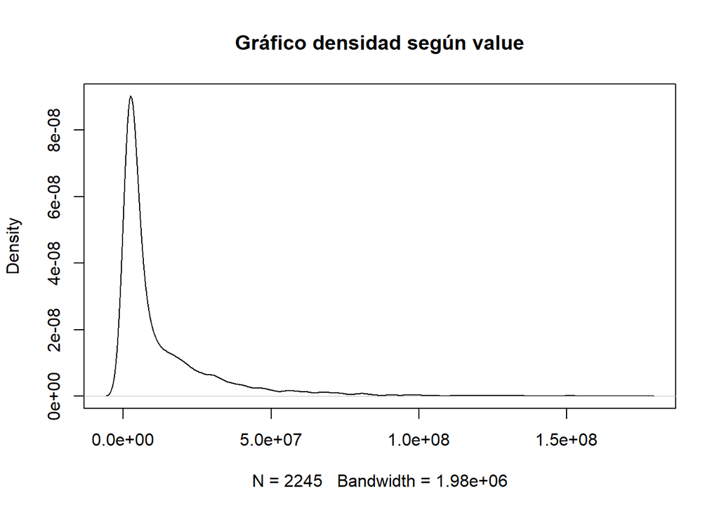

```r
ffemale_full <- ffemale_full %>% mutate(lvalue = log(value))

plot(density(ffemale_full$value, na.rm = TRUE), main = "Gráfico densidad según value")
```

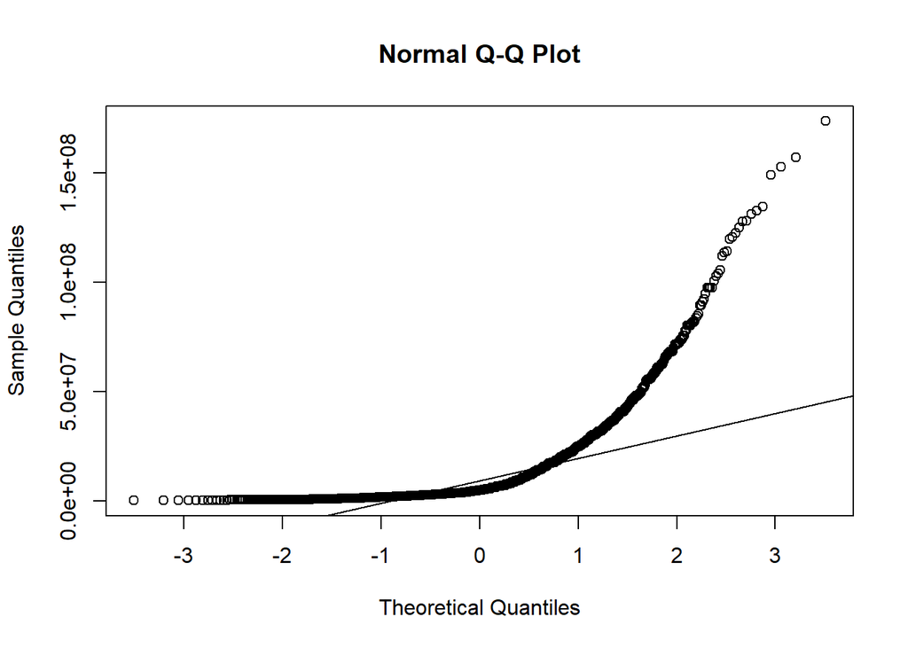

```r
qqnorm(ffemale_full$value); qqline(ffemale_full$value)
```

Primeramente ya podemos ver un gráfico de densidad que concentra muchas de sus muestras al principio y la sigue una cola hasta valores más altos, lo cual no se adecúa mucho a una distribución normal, cosa que vemos mejor en el qqplot, donde a partir del cuantil 1 empieza a alejarse de la línea dibujada.

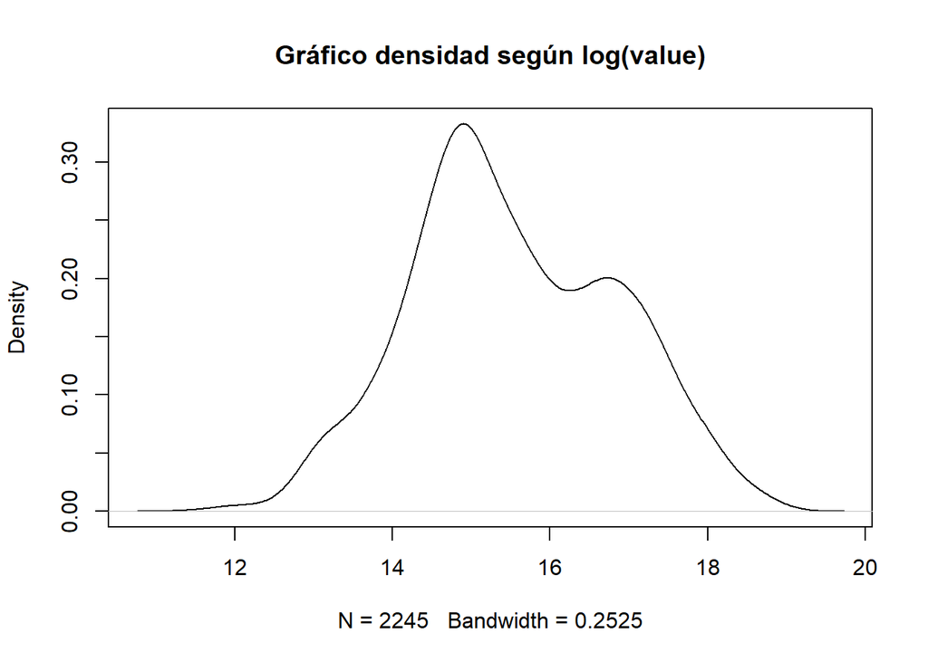

```r
plot(density(ffemale_full$lvalue, na.rm = TRUE), main = "Gráfico densidad según log(value)")
```

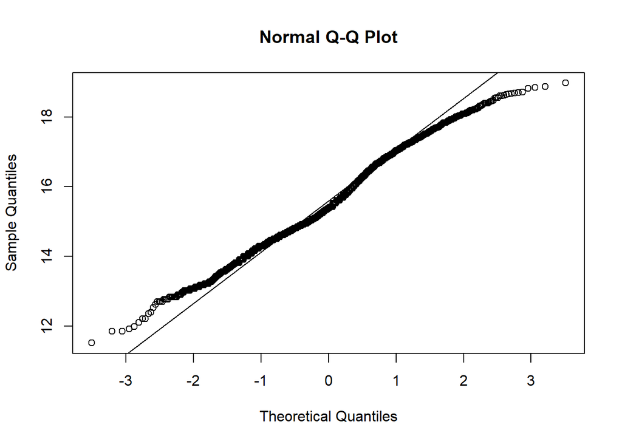

```r
qqnorm(ffemale_full$lvalue); qqline(ffemale_full$lvalue)
```

En estas gráficas en cambio ya vemos más cambios. La gráfica de densidad ya concentra mejor sus datos asemejándose a una ditribución normal y el qqplot mostrado tiene los puntos más cerca de la línea diagonal dibujada.

## 3.2 Regresión lineal múltiple

Crear un modelo de regresión lineal según las variables explicativas overall, potential, age, wage y release_clause sobre la variable independiente lvalue.

```r
model_data <- ffemale_full %>%
  select(lvalue, overall, potential, age, wage, release_clause)

modelo <- lm(lvalue ~ overall + potential + age + wage + release_clause, data = model_data)
summary(modelo)
```

```
##
## Call:
## lm(formula = lvalue ~ overall + potential + age + wage + release_clause,
##     data = model_data)
##
## Residuals:
##      Min       1Q   Median       3Q      Max
## -1.47375 -0.13228  0.00743  0.16414  0.86451
##
## Coefficients:
##                  Estimate Std. Error t value Pr(>|t|)
## (Intercept)     1.511e+00  1.171e-01  12.904  < 2e-16 ***
## overall         1.887e-01  2.225e-03  84.774  < 2e-16 ***
## potential       2.463e-02  2.139e-03  11.513  < 2e-16 ***
## age            -7.640e-02  2.398e-03 -31.863  < 2e-16 ***
## wage            9.638e-05  2.549e-05   3.781  0.00016 ***
## release_clause  1.383e-09  2.633e-10   5.250 1.66e-07 ***
## ---
## Signif. codes:  0 '***' 0.001 '**' 0.01 '*' 0.05 '.' 0.1 ' ' 1
##
## Residual standard error: 0.2326 on 2211 degrees of freedom
##   (28 observations deleted due to missingness)
## Multiple R-squared:  0.9688, Adjusted R-squared:  0.9687
## F-statistic: 1.373e+04 on 5 and 2211 DF,  p-value: < 2.2e-16
```

Según el modelo podemos sacar varias conclusiones sobre las variables explicativas.

- (Intercept): Es el valor que tenemos cuando el resto es 0, moviendose el lvalue en una media de 15 tampoco nos dice mucho del modelo
- overall: La media de calidad de las jugadoras que suele estar entre 70-90 aumenta en 0.188 por cada unidad, lo cual la hace una de las variables con más peso en la predicción ya que solo esta variable ya pone su valor logaritmico entre 13 y 17, si vemos la gráfica de densidad estos son valores extremos de la distribución.
- potential: el potencial de las jugadoras influye en un 0.024 por cada unidad que aumenta el valor no siendo tan explicativa como la anterior pero bastante significativa para el modelo.
- age: la edad es la única variable negativa del modelo, así, cuanto más joven es una jugadora mayor es su valor ya que “pierde” valor con los años.
- wage: su sueldo es una de las variables que menos afecta al modelo como vemos en su p-valor aunque sigue siendo significativa.
- release_clause: Por último su clausula es la que vemos que menos varía según el valor del atributo pero es el atributo con los valores más altos. Aún así tampoco es de las más significativas del modelo.

Por lo general, con p-valores de cada atributo y el p-valor del modeo en sí podemos ver como este sí es modelo que predice bien el valor de las jugadoras.

### 3.2.1 Multicolinealidad

Nos piden a continuación explicar si existe colineadlidad entre las variables explicativas del modelo, pudiendo mirar tanto su matriz de correlación como su vif(factor de inflación de la varianza), para este último voy a basarme en la interpretación del siguiente enlace. https://www.datacamp.com/es/tutorial/variance-inflation-factor

```r
cor(model_data)
```

```
##                   lvalue   overall  potential        age      wage
## lvalue         1.0000000 0.9382191  0.8292924  0.2333045 0.7052782
## overall        0.9382191 1.0000000  0.6786892  0.5144601 0.7295370
## potential      0.8292924 0.6786892  1.0000000 -0.1590820 0.4954619
## age            0.2333045 0.5144601 -0.1590820  1.0000000 0.3949775
## wage           0.7052782 0.7295370  0.4954619  0.3949775 1.0000000
## release_clause        NA        NA         NA         NA        NA
##                release_clause
## lvalue                     NA
## overall                    NA
## potential                  NA
## age                        NA
## wage                       NA
## release_clause              1
```

En cuanto a su matriz de correlación podemos darnos cuenta de algunas cosas. El overall está muy relacionado con el lvalue, cosa que se ha mencionado antes que era la variable que más explicaba el modelo siendo su correlación de un 0.938. Las siguientes variables más relacionadas son el potencial de la jugadora y su valor. Su sueldo y el overall, están directamente correlacionadas así como el sueldo y su valor, cuando más aumenta uno también lo hace el otro.

```r
vif(modelo)
```

```
##        overall      potential            age           wage release_clause
##       8.818450       5.517383       4.449613       4.042139       4.918407
```

Mirando el factor de la inflación de la varianza vemos más de lo mismo. Overall es el valor más alto y cercano a un valor de 10 lo que indica muy alta multicolinealidad con el valor a predecir del valor de las jugadoras. Además su potencial también tiene un factor de inflación superior a 5 y un poco por detrás de este su clausula también cercana a 5 lo que nos dice la existencia de esta multicolinealidad alta. Para las otras variables también es moderada lo que nos dice que todas las variables se relacionan bastante con el valor a predecir.

# 4. ANOVA unifactorial

```r
ffemale_full <- ffemale_full %>%
  mutate(
    league = case_when(
      league_name == "Women's Super League" ~ "SuperL",
      league_name == "Primera Division Women" ~ "PrimeraD",
      league_name == "Feminine Division 1" ~ "FeminineD",
      league_name == "Bundesliga Women" ~ "Bundesliga",
      league_name == "NWSL" ~ "NWSL",
      TRUE ~ "Resto"
    ),
    league = as.factor(league)
  )
```

## 4.1 Visualización

Una vez separado se nos pide hacer una visualización sobre su lvalue medio para compararlas con la función ggline.

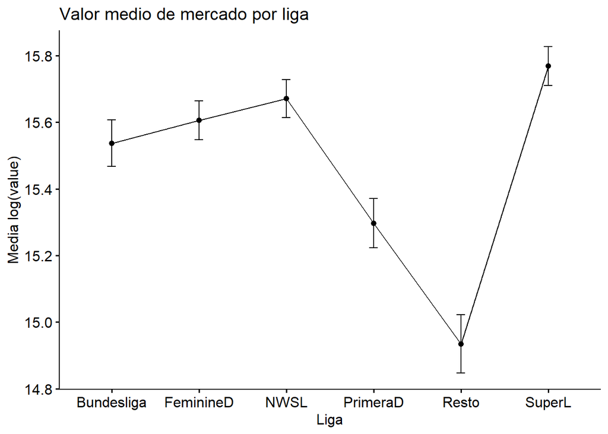

```r
# Visualización con ggline
ggline(ffemale_full, x = "league", y = "lvalue",
       add = "mean_se",
       ylab = "Media log(value)", xlab = "Liga",
       title = "Valor medio de mercado por liga")
```

## 4.2 Hipótesis nula y alternativa

- $H_0$: Todas las ligas tienen el mismo valor medio de mercado.
  $$H_0: \mu_1 = \mu_2 = \cdots =
  \mu_k$$
- $H_1$: Al menos una liga tiene un valor medio de mercado diferente a las demás.
  $$H_1: \exists\, i, j \text{ tal que } \mu_i
  \neq \mu_j$$

## 4.3 Modelo

```r
anova_model <- aov(lvalue ~ league, data = ffemale_full)
summary(anova_model)
```

```
##               Df Sum Sq Mean Sq F value   Pr(>F)
## league         5    125  24.963   14.94 1.91e-14 ***
## Residuals   2239   3742   1.671
## ---
## Signif. codes:  0 '***' 0.001 '**' 0.01 '*' 0.05 '.' 0.1 ' ' 1
```

```r
# ANOVA con lm
lm_model <- lm(lvalue ~ league, data = ffemale_full)
taov <- summary(anova_model)
taov
```

```
##               Df Sum Sq Mean Sq F value   Pr(>F)
## league         5    125  24.963   14.94 1.91e-14 ***
## Residuals   2239   3742   1.671
## ---
## Signif. codes:  0 '***' 0.001 '**' 0.01 '*' 0.05 '.' 0.1 ' ' 1
```

## 4.4 Profundizando en ANOVA

```r
ssb <- taov[[1]]['league', 'Sum Sq']
ssw <- taov[[1]]['Residuals', 'Sum Sq']
sst <- ssb + ssw

alp <- taov[[1]]['league', 'Df']
n_1 <- taov[[1]]['Residuals', 'Df']

# Calcular cuadrados medios
msa <- ssb / alp
mse <- ssw / n_1

f_value <- msa / mse

# Valor crítico F al 95%
f_crit <- qf(0.95, df1 = alp, df2 = n_1)

# p-valor
p_val <- pf(f_value, df1 = alp, df2 = n_1, lower.tail = FALSE)

cat("Between Sum of Square (SSB):", round(ssb, 4), "\n")
```

```
## Between Sum of Square (SSB): 124.8141
```

```r
cat("Within Sum of Squares (SSW):", round(ssw, 4), "\n")
```

```
## Within Sum of Squares (SSW): 3742.318
```

```r
cat("Total Sum of Squares (SST):", round(sst, 4), "\n\n")
```

```
## Total Sum of Squares (SST): 3867.132
```

```r
cat("F-valor:", round(f_value, 4), "\n")
```

```
## F-valor: 14.9351
```

```r
cat("Valor crítico F (alfa=0.05):", round(f_crit, 4), "\n")
```

```
## Valor crítico F (alfa=0.05): 2.2181
```

```r
cat("p-valor:", format.pval(p_val, digits = 4), "\n")
```

```
## p-valor: 1.907e-14
```

## 4.5 Efectos de los niveles del factor y fuerza de relación

```r
n2 <- ssb / sst
cat("Tamaño del efecto:", round(n2, 4), "\n")
```

```
## Tamaño del efecto: 0.0323
```

```r
model.tables(anova_model, type="effects")
```

```
## Tables of effects
##
##  league
##     Bundesliga FeminineD     NWSL PrimeraD    Resto   SuperL
##      -0.002821   0.06579   0.1311  -0.2436  -0.6059   0.2285
## rep 303.000000 514.00000 324.0000 376.0000 180.0000 548.0000
```

Este valor del tamaño del efecto indica que aproximadamente el 3.23% de la variabilidad total en el valor se explica por el factor de league.

La tabla nos explica, sobre cada liga cuanto distan sobre la media del valor, como podemos comprobar también en el gráfico, la SuperL y la NWSL están por encima del resto de ligas con un valor más elevado y “Resto”, todas las lisgas que no hemos estudiado, están muy por debajo de la media.

# 5. Comparaciones múltiples

```r
pairwise.t.test(ffemale_full$lvalue, ffemale_full$league, p.adjust.method = "bonferroni")
```

```
##
##  Pairwise comparisons using t tests with pooled SD
##
## data:  ffemale_full$lvalue and ffemale_full$league
##
##           Bundesliga FeminineD NWSL    PrimeraD Resto
## FeminineD 1.0000     -         -       -        -
## NWSL      1.0000     1.0000    -       -        -
## PrimeraD  0.2388     0.0064    0.0020  -        -
## Resto     1.2e-05    3.5e-08   1.5e-08 0.0302   -
## SuperL    0.1875     0.6070    1.0000  8.2e-07  1.2e-12
##
## P value adjustment method: bonferroni
```

- El grupo “Resto” tiene un valor medio de mercado significativamente diferente en comparación con casi todas las ligas. La más cercana a esta es PrimeraD aunque también hay diferencias.
- Hay diferencias significativas entre FeminineD y PrimeraD.
- Hay diferencias significativas entre PrimeraD, tanto con NWSL y con SuperL.
- No hay diferencias significativas entre algunas ligas como Bundesliga, FeminineD y NWSL entre ellas. Esta última, NWSL tampoco tiene mucha diferencia con SuperL.
- Con estos resultados podemos intuir un poco el orden de estas ligas, estando tanto “Resto” como SuperL en los extremos, aunque no cual es mayor y cual menor si no atendemos al gráfico del apartado anterior.
- Estos datos nos indican que sí existen diferencias importantes entre los valores medios de cada liga, pero no entre todas a la vez, solo algunas.

# 6. ANOVA multifactorial

## 6.1 Análisis visual de los efectos principales y posibles interacciones

```r
ffemale_full <- ffemale_full %>% mutate(international = ifelse(!is.na(nation_team_id), "Sí", "No"))

tabla_interaccion <- ffemale_full %>%
  group_by(league, international) %>%
  summarise(
    media = mean(lvalue, na.rm = TRUE),
    sd = sd(lvalue, na.rm = TRUE),
    n = n(),
    .groups = "drop"
  )

print(tabla_interaccion)
```

```
## # A tibble: 12 × 5
##    league     international media    sd     n
##    <fct>      <chr>         <dbl> <dbl> <int>
##  1 Bundesliga No             15.3 1.10    271
##  2 Bundesliga Sí             17.3 0.817    32
##  3 FeminineD  No             15.4 1.19    459
##  4 FeminineD  Sí             17.5 0.948    55
##  5 NWSL       No             15.5 0.954   281
##  6 NWSL       Sí             16.7 0.887    43
##  7 PrimeraD   No             15.1 1.35    336
##  8 PrimeraD   Sí             17.0 0.963    40
##  9 Resto      No             14.8 1.14    157
## 10 Resto      Sí             15.9 0.939    23
## 11 SuperL     No             15.4 1.28    413
## 12 SuperL     Sí             16.8 0.992   135
```

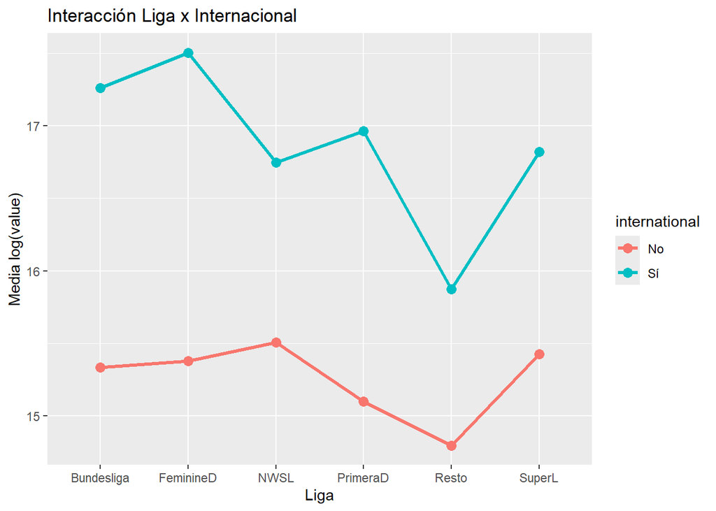

```r
ggplot(tabla_interaccion, aes(x = league, y = media, color = international, group = international)) +
  geom_line(size=1.2) + geom_point(size=3) +
  labs(y = "Media log(value)", x = "Liga", title = "Interacción Liga x Internacional")
```

Con la tabla nos damos una pequeña idea de los datos y vemos que no hay muchos datos sobre jugadoras internacionales en algunas ligas, sin embargo, mirando el gráfico podemos sacar conclusiones más importantes Por ejemplo:

- En todas las ligas, el valor de las jugadoras internacionales es bastante superior a las que no lo son.
- El “Resto” de ligas, las que no estudiamos en el conjunto en ambas medias tienen los valores más bajos.
- Tanto la SuperL como la NWSL tienen medias parecidas si son o no internacionales en sus respectivos grupos.
- La FemenineD es la que más valor tiene con jugadoras internacionales y en la que más diferencia se ve con jugadoras de su propio país.

## 6.2 y 6.3 Cálculo e interpretación del modelo

```r
modelo_multi <- aov(lvalue ~ league * international, data = ffemale_full)
summary(modelo_multi)
```

```
##                        Df Sum Sq Mean Sq F value   Pr(>F)
## league                  5  124.8    25.0   18.52  < 2e-16 ***
## international           1  698.2   698.2  517.87  < 2e-16 ***
## league:international    5   33.7     6.7    5.00 0.000147 ***
## Residuals            2233 3010.4     1.3
## ---
## Signif. codes:  0 '***' 0.001 '**' 0.01 '*' 0.05 '.' 0.1 ' ' 1
```

Del siguiente modelo podemos sacar varias conlusiones.

- En referencia a la liga, como veíamos en apartados anteriores, sí existen diferencias claras en el valor medio de mercado entre ligas.
- Ser una jugadora internacional bastante en el valor de mercado, cosa que nois dice el F-valor y también viendo el gráfico del apartado anterior, así, una jugadora internacional vale más que una del mismo país de la liga que juega.
- El efecto de ser internacional no es igual en todas las ligas según el p-valor. Cosa que también se puede ver en el gráfica del apartado 6.1, no significa que algunas de ellas no guardan relación entre sí, pero al menos hay una relación muy diferente a otra.

## 7 Resumen ejecutivo

A lo largo de este ejercicio han podido estudiarse el valor de las jugadoras según los datos que tenemos existentes y hemos podido sacar varias conclusiones al respecto.

- Tras corroborarlo, hemos podido observar que el valor medio de las jugadoras que tienen una posición ofensiva es bastante superior al resto de jugadoras por lo general.
- Mirando el valor de las jugadoras hemos sacado visto que el overall que se le da a la jugadora, su puntuación, es uno de los factores que más influye en su valor de mercado.
- Su potencial es una de las cosas que también más influye y como se puede intuir, cuanto más joven sea una jugadora mayor será su precio, aunque tenga una mayor experiencia jugando que otras de sus compañeras su proyección de futuro es superior al resto.

Tras estos estudios nos hemos centrado también en la influencia de las grandes ligas con respecto al valor de las jugadoras. Hemos dividido las ligas en la SuperL, PrimeraD, FeminineD, Bundesliga y la NWSL, las ligas más importantes del fútbol femenino y al resto las hemos juntado también como otra variable más. De este estudio podemos destacar los siguientes puntos:

- Como media, el resto de ligas que no son de las cinco grandes tienen un valor de mercado de jugadoras inferior al resto.
- De estas 5 grandes ligas, la SuperL es la liga donde mayor valor de mercado medio existe por jugadora y la primera división española la que menos. Las otras tres tienen valores medios bastante parecidos entre sí.

Además hemos podido estudiar la influencia de jugadoras internacionales en estos 6 grupos.

No en todas las ligas se comportan igual los valores de jugadoras internacionales. Decíamos que la SuperL de inglaterra tenía el valor medio más alto de jugadoras, sin embargo, no es ni la que más valor medio tienen sus jugadoras, ya sean nacionales como internacionales. Su valor medio más alto se debe a que sí es la liga con menor diferencia entre número de jugadoras nacionales(413) como internacionales(135).

En cuanto a jugadoras internacionales, la FemenineD francesa es la liga donde, de media, mayor valor tienen las jugadoras internacionales.

Y por último, el resto de ligas que no son de las grandes cinco son las que menor valor de mercado tienen sus jugadoras, tanto nacionales como internacionales.